# Evolutionary algorithms (EAs)

## Materials

[Grekousis, George, and Ye Liu. "Where will the next emergency event occur? Predicting ambulance demand in emergency medical services using artificial intelligence." Computers, Environment and Urban Systems 76 (2019): 110-122.](https://www.sciencedirect.com/science/article/pii/S0198971519300146?casa_token=nOA5Y7zefdEAAAAA:juabqS6HLYtWJL0wqC_SohHLCl0iOJwa8dHZwoH0D_1gRq65STtan7BHOKsvK3pCYXyj_S-Urw)

## Introduction

Evolutionary algorithm (EA) is a subset of evolutionary computation, it inspired by biological evolution, such as **reproduction, mutation, recombination, and selection.**

### Features

1. Evolutionary algorithms often perform well **approximating solutions** to all types of problems because they ideally **do not make any assumption about the underlying fitness landscape.**
2. In most real applications of EAs, **computational complexity** is a prohibiting factor.
3. Fitness approximation is one of the solutions to overcome this difficulty.

## Implementation

Here is an implementation of a single-objective genetic algorithm

- **Step One**: Generate the initial population of individuals randomly. (First generation)
- **Step Two**: Repeat the following regenerational steps until termination:
  1. **Evaluate the fitness** of each individual in the population (time limit, sufficient fitness achieved, etc.)
  2. Select the **fittest individuals for reproduction.** (Parents)
  3. **Breed new individuals** through crossover and mutation operations to give birth to offspring.
  4. **Replace the least-fit individuals** of the population with new individuals.

## Examples

1. Generate the **initial** population of N individual **MLP ANNs randomly**.
2. **Train, validate, and test** the MLP ANNs of the generation using early stopping and L1 regularization, and calculate the cost function for each one of them (MSE). **Sort the ANNs by MSE in ascending order.**
3. **Select the top X% of the ANNs** (with less MSE). **Randomly select additional (X/2)% ANNs**
4. Apply a mutation operator with a probability of Y% a. **Mutation is used to randomly change the values of some hyperparameters of a fraction (Y%)** of the selected ANNs
5. **Apply a recombination operator** with a probability of Z% to give birth to offspring. a. In particular, for any given set of two ANNs, we name the first ANN the “father” and the second the “mother.” b. The **first child inherits the same hyper-parameter values for the learning rate, the L1, and the momentum from the mother** and inherits the rest from the father. c. The **second child inherits the same hyper-parameter values for the learning rate, the L1, and the momentum from the father,** and in- herits the rest from the mother.
6. **Replace the worst ANNs** of the population with the offspring and create a new generation.
7. Go to step 2 or stop when nothing further can be improved to minimize the MSE or when the total number of generations is reached

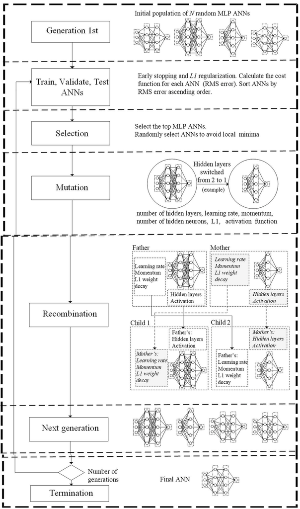